# NXS TCS Article — Embedding Report

SPECTER2 embeddings, keypaper-similarity scoring

Author

Rainer M. Krug

Published

July 9, 2026

```r
library(targets)
library(htmltools)
library(knitr)
```

# Embeddings Overview

The corpus contains the following missing titles and abstracts

```r
ds <- arrow::open_dataset(tar_read(corpus_chapter))
n_total <- nrow(ds)
n_na <- ds |> dplyr::filter(is.na(title)) |> nrow()
n_empty <- ds |> dplyr::filter(!is.na(title), title == "") |> nrow()
n_present <- n_total - n_na - n_empty

tibble::tibble(
  state = c("title present", "title empty (nchar=0)", "title NA", "total"),
  n = c(n_present, n_empty, n_na, n_total)
) |>
  dplyr::mutate(`%` = 100 * n / n_total) |>
  knitr::kable(
    digits = 3,
    format.args = list(big.mark = ",", nsmall = 3),
    align = c("l", "r", "r"),
    caption = "Title presence in the OpenAlex corpus extract. Works in NA or empty rows are dropped from the title-variant embedding by preprocessor_title()."
  )
```

Table 1: Title presence in the OpenAlex corpus extract. Works in NA or empty rows are dropped from the title-variant embedding by preprocessor_title().

| state | n | % |
| --- | --- | --- |
| title present | 18,388.000 | 100.000 |
| title empty (nchar=0) | 0.000 | 0.000 |
| title NA | 0.000 | 0.000 |
| total | 18,388.000 | 100.000 |

```r
ds <- arrow::open_dataset(tar_read(corpus_chapter))
n_total <- nrow(ds)
n_na <- ds |> dplyr::filter(is.na(abstract)) |> nrow()
n_empty <- ds |> dplyr::filter(!is.na(abstract), abstract == "") |> nrow()
n_present <- n_total - n_na - n_empty

tibble::tibble(
  state = c(
    "abstract present",
    "abstract empty (nchar=0)",
    "abstract NA",
    "total"
  ),
  n = c(n_present, n_empty, n_na, n_total)
) |>
  dplyr::mutate(`%` = 100 * n / n_total) |>
  knitr::kable(
    digits = 3,
    format.args = list(big.mark = ",", nsmall = 3),
    align = c("l", "r", "r"),
    caption = "Abstract presence in the OpenAlex corpus extract. Works without abstracts are dropped from the abstract and title_abstract variants."
  )
```

Table 2: Abstract presence in the OpenAlex corpus extract. Works without abstracts are dropped from the abstract and title_abstract variants.

| state | n | % |
| --- | --- | --- |
| abstract present | 12,932.000 | 70.328 |
| abstract empty (nchar=0) | 0.000 | 0.000 |
| abstract NA | 5,456.000 | 29.672 |
| total | 18,388.000 | 100.000 |

The following number of embeddings were determined.

```r
# Embeddings root holds multiple config=<name>/ partitions

emb_meta <- dirname(dirname(dirname(tar_read(emb_corpus_title)))) |>
  arrow::open_dataset() |>
  dplyr::count(config, source, variant) |>
  dplyr::collect() |>
  tidyr::pivot_wider(names_from = variant, values_from = n, values_fill = 0L) |>
  dplyr::relocate(
    dplyr::any_of(c("title", "abstract", "title_abstract")),
    .after = source
  ) |>
  dplyr::arrange(config, source)


# Total works available per source (before embedding). Three sources now:
#   corpus_chapter — the full assessment reference libraries
#   corpus         — the works CITED inside the definitions (cited corpus)
#   keypaper       — the TCA/Nexus concept definitions
n_corpus_chapter <- nrow(arrow::open_dataset(tar_read(corpus_chapter)))
n_corpus_cited <- nrow(arrow::open_dataset(tar_read(corpus)))
n_keypaper <- nrow(arrow::open_dataset(tar_read(key_works)))

emb_meta <- emb_meta |>
  dplyr::mutate(
    corpus_size = dplyr::case_when(
      source == "corpus_chapter" ~ n_corpus_chapter,
      source == "corpus" ~ n_corpus_cited,
      source == "keypaper" ~ n_keypaper,
      TRUE ~ NA_integer_
    )
  ) |>
  dplyr::arrange(config, source) |>
  dplyr::relocate(corpus_size, .after = source)

# Map config name → model_id for the caption
cfg <- yaml::read_yaml("input/config.yaml")
active_cfg <- cfg$embeddings$active
model_ids <- vapply(
  cfg$embeddings$configs,
  function(c) c$model %||% NA_character_,
  character(1)
)

knitr::kable(
  emb_meta,
  format.args = list(big.mark = ","),
  caption = sprintf(
    "Embedded works per config × source × variant. Active config: %s (model_id = %s).",
    active_cfg,
    model_ids[[active_cfg]]
  )
)
```

Embedded works per config × source × variant. Active config: SPECTER2_runpod (model_id = allenai/specter2_proximity_merged).

| config | source | corpus_size | title | abstract | title_abstract |
| --- | --- | --- | --- | --- | --- |
| SPECTER2_runpod | corpus | 1,826 | 1,826 | 1,355 | 1,355 |
| SPECTER2_runpod | corpus_chapter | 18,388 | 18,388 | 12,932 | 12,932 |
| SPECTER2_runpod | keypaper | 161 | 161 | 161 | 161 |

## Citation extraction & resolution

Inline citations were extracted from the concept definitions (regex) and resolved to works in the *matching assessment’s* reference library in two passes — `strict` (first-author surname + exact year) then `loose` (fuzzy surname, year ±1). The distinct resolved works form the new **cited corpus** (`corpus`); works still `unmatched` after both passes are retained for manual verification. Coverage per keyset:

```r
res <- arrow::open_dataset(tar_read(citations_resolved)) |> dplyr::collect()
res |>
  dplyr::count(keyset, match_pass) |>
  tidyr::pivot_wider(names_from = match_pass, values_from = n,
                     values_fill = 0L) |>
  dplyr::mutate(
    total = rowSums(dplyr::across(dplyr::any_of(
      c("strict", "loose", "unmatched")
    ))),
    `resolved %` = 100 * (total - dplyr::coalesce(unmatched, 0L)) / total
  ) |>
  knitr::kable(
    digits = 1, format.args = list(big.mark = ","),
    caption = sprintf(
      paste0("Citation resolution by keyset. Cited corpus: %s distinct works ",
             "embedded (source=corpus)."),
      format(nrow(arrow::open_dataset(tar_read(corpus))), big.mark = ",")
    )
  )
```

Table 3: Citation resolution by keyset. Cited corpus: 1,826 distinct works embedded (source=corpus).

| keyset | loose | strict | unmatched | total | resolved % |
| --- | --- | --- | --- | --- | --- |
| Nexus_Response_Options | 109 | 1,398 | 48 | 1,555 | 96.9 |
| TCA_Actions_Ch5 | 40 | 515 | 39 | 594 | 93.4 |
| TCA_Annex_3_3 | 88 | 151 | 91 | 330 | 72.4 |
| TCA_Approaches_3_2 | 10 | 141 | 17 | 168 | 89.9 |

## Language distribution

SPECTER2 is a primarily English model; non-English works can still embed but their similarity scores are less reliable. Useful gut-check on how much of the corpus the embedding is well-suited for.

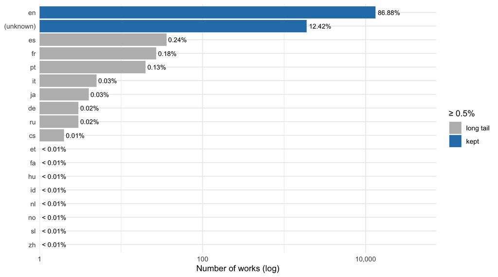

Figure 1: Works per OpenAlex `language`, log x-axis. Blue bars = ≥ 0.5% of the corpus; grey = long tail. SPECTER2 was trained primarily on English; treat similarity scores for low-resource languages with caution.

```r
tar_read(viz_language_fig)
```

## Input text length per variant

How long is the text actually sent to TEI? `title_abstract` is capped on the title side at `title_cap_combined` chars (config), then joined with the abstract via `[SEP]`. Works far above ~2000 chars may hit the model’s 512-token context window and get silently truncated server-side.

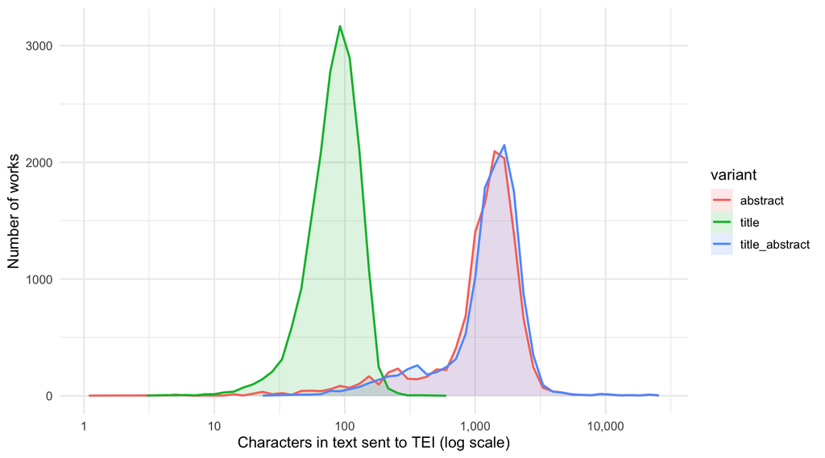

```r
tar_read(viz_text_length_fig)
```

### Silent truncation by TEI

SPECTER2 truncates input above ~512 tokens (~2,000 characters) **without warning**. Embeddings for truncated works are based only on the first 2k characters of text — methodologically worth surfacing.

```r
tar_read(viz_truncation_stats) |>
  knitr::kable(
    format.args = list(big.mark = ","),
    caption = "Number of works exceeding length thresholds per variant. The `> 2048` column approximates how many were silently truncated by TEI."
  )
```

Table 4: Number of works exceeding length thresholds per variant. The `> 2048` column approximates how many were silently truncated by TEI.

| variant | n | > 1024 | > 2048 | > 4096 | % > 2048 |
| --- | --- | --- | --- | --- | --- |
| title | 18,388 | 0 | 0 | 0 | 0.000 |
| abstract | 12,932 | 8,922 | 1,475 | 112 | 11.406 |
| title_abstract | 12,932 | 9,575 | 1,862 | 117 | 14.398 |

# Work-type breakdown

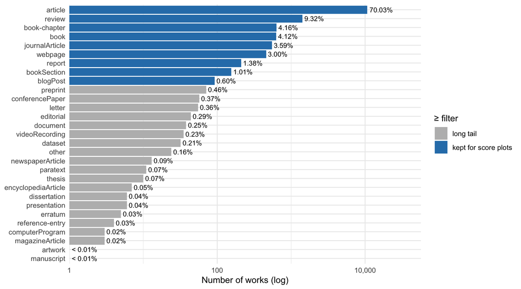

Figure 3: Number of works per OpenAlex `type`, log x-axis. Blue bars = types representing ≥ 0.5% of the corpus; grey = long-tail types.

```r
tar_read(viz_type_count_fig)
```

# Variant agreement

If `title` and `abstract` agree on a work’s relevance, the title is a reliable proxy for the abstract. Off-diagonal works are interesting candidates for manual inspection: either the title misrepresents the paper or the abstract is poor quality.

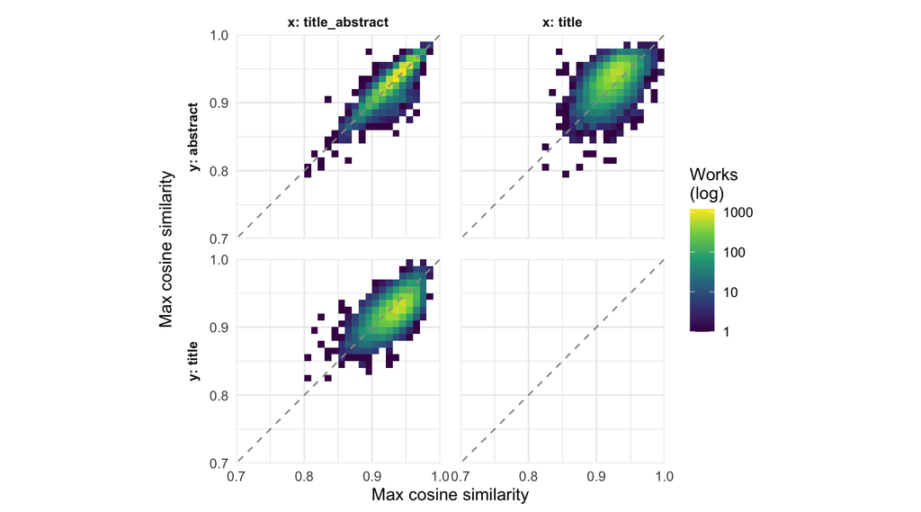

```r
tar_read(viz_agree_fig)
```

# Sanity check: embedding L2 norms

SPECTER2 should return roughly normalised vectors (norm ≈ 1). A tight peak near 1 means the model behaved as expected; outliers or zero-norm vectors would indicate problems (empty input, model failures). Sampled to 50k per (source, variant) — sufficient for a histogram.

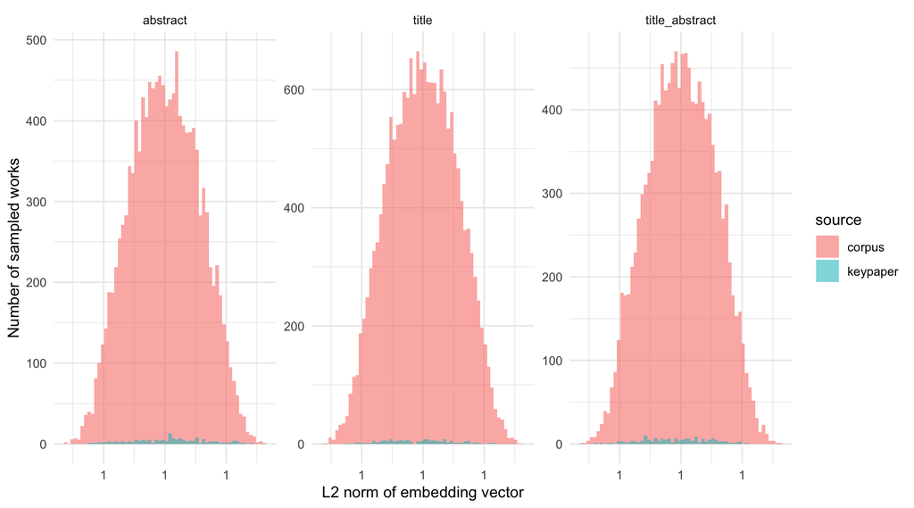

Figure 5: Distribution of L2 norms of embedding vectors per (source × variant), sampled to 50,000 rows per leaf, seed = 13. Expect a tight peak — outliers or wide spread suggest input or model issues.

```r
tar_read(viz_emb_norm_fig)
```

# Provenance

Everything needed to reproduce this report.

```r
cfg <- yaml::read_yaml("input/config.yaml")
active_cfg <- cfg$embeddings$active
emb_cfg <- cfg$embeddings$configs[[active_cfg]]

# Embedding dimension from one parquet file
emb_dim <- {
  one_file <- list.files(
    dirname(tar_read(emb_corpus_title)),
    pattern = "\\.parquet$",
    full.names = TRUE,
    recursive = TRUE
  )[[1]]
  v_cols <- grep(
    "^V[0-9]+$",
    names(arrow::open_dataset(one_file)),
    value = TRUE
  )
  length(v_cols)
}

git_sha <- tryCatch(
  trimws(system("git rev-parse --short HEAD", intern = TRUE)),
  error = function(e) "unknown"
)

tibble::tibble(
  field = c(
    "active embedding config",
    "model id",
    "embedding dimension",
    "title cap (chars, combined variant)",
    "separator token",
    "TEI host",
    "report rendered",
    "git commit"
  ),
  value = c(
    active_cfg,
    emb_cfg$model %||% "—",
    as.character(emb_dim),
    as.character(emb_cfg$title_cap_combined %||% "—"),
    emb_cfg$sep_token %||% "—",
    paste0(emb_cfg$scheme %||% "http", "://", emb_cfg$host),
    format(Sys.time(), "%Y-%m-%d %H:%M:%S %Z"),
    git_sha
  )
) |>
  knitr::kable(
    caption = "Run provenance — paste into the methods section verbatim."
  )
```

Table 5: Run provenance — paste into the methods section verbatim.

| field | value |
| --- | --- |
| active embedding config | SPECTER2_runpod |
| model id | allenai/specter2_proximity_merged |
| embedding dimension | 768 |
| title cap (chars, combined variant) | 200 |
| separator token | [SEP] |
| TEI host | https://fcb12v29f8dykn-8080.proxy.runpod.net |
| report rendered | 2026-07-09 13:19:19 CEST |
| git commit | 3716047 |